# Linear Models Basics

Alex Damisch

August 28, 2015

## Getting Started

We will examine variables from the `NBAPlayers2011` dataset, found in the `Lock5Data` package. We will also need the `ggplot2` package for graphics.

```r
library(Lock5Data)
data(NBAPlayers2011)
library(ggplot2)
```

This data set has 25 variables, which is larger than many of the data sets you may have looked at in the past. We can still use many of the same strategies to examine it.

```r
head(NBAPlayers2011)
```

```
##              Player Age Team Games Starts Mins MinPerGame FGMade FGAttempt
## 1       Monta Ellis  25  GSW    80     80 3227       40.3    726      1611
## 2          Rudy Gay  24  MEM    54     54 2152       39.9    409       869
## 3 LaMarcus Aldridge  25  POR    81     81 3211       39.6    707      1415
## 4         Luol Deng  25  CHI    82     82 3208       39.1    531      1155
## 5      Kevin Durant  22  OKC    78     78 3038       38.9    711      1538
## 6      LeBron James  26  MIA    79     79 3063       38.8    758      1485
##   FGPct FG3Made FG3Attempt FG3Pct FTMade FTAttempt FTPct OffRebound
## 1 0.451     137        379  0.361    340       431 0.789         44
## 2 0.471      57        144  0.396    194       241 0.805         82
## 3 0.500       4         23  0.174    351       444 0.791        278
## 4 0.460     115        333  0.345    253       336 0.753        116
## 5 0.462     145        414  0.350    594       675 0.880         57
## 6 0.510      92        279  0.330    503       663 0.759         80
##   DefRebound Rebounds Assists Steals Blocks Turnovers Fouls Points
## 1        237      281     450    168     23       252   203   1929
## 2        254      336     153     91     58       135   131   1069
## 3        431      709     170     82     94       153   220   1769
## 4        360      476     230     78     48       156   162   1430
## 5        476      533     214     88     76       218   159   2161
## 6        510      590     554    124     50       284   163   2111
```

```r
summary(NBAPlayers2011)
```

```
##               Player         Age             Team         Games
##  Al Horford      :  1   Min.   :20.00   DEN    :  8   Min.   :13.00
##  Al Jefferson    :  1   1st Qu.:24.00   TOR    :  8   1st Qu.:67.00
##  Amare Stoudemire:  1   Median :26.00   CLE    :  7   Median :75.00
##  Amir Johnson    :  1   Mean   :26.73   LAC    :  7   Mean   :70.95
##  Anderson Varejao:  1   3rd Qu.:29.25   MIL    :  7   3rd Qu.:80.00
##  Andray Blatche  :  1   Max.   :38.00   NJN    :  7   Max.   :82.00
##  (Other)         :170                   (Other):132
##      Starts           Mins        MinPerGame        FGMade
##  Min.   : 0.00   Min.   : 345   Min.   :24.00   Min.   : 42.0
##  1st Qu.:39.75   1st Qu.:1965   1st Qu.:27.15   1st Qu.:263.5
##  Median :64.00   Median :2254   Median :31.20   Median :354.0
##  Mean   :55.98   Mean   :2212   Mean   :31.02   Mean   :369.2
##  3rd Qu.:77.00   3rd Qu.:2601   3rd Qu.:34.70   3rd Qu.:442.2
##  Max.   :82.00   Max.   :3227   Max.   :40.30   Max.   :758.0
##
##    FGAttempt          FGPct           FG3Made         FG3Attempt
##  Min.   :  86.0   Min.   :0.3610   Min.   :  0.00   Min.   :  0.0
##  1st Qu.: 581.0   1st Qu.:0.4298   1st Qu.:  3.00   1st Qu.: 15.0
##  Median : 780.0   Median :0.4520   Median : 64.50   Median :181.5
##  Mean   : 795.5   Mean   :0.4646   Mean   : 61.49   Mean   :169.7
##  3rd Qu.: 978.2   3rd Qu.:0.5000   3rd Qu.:105.00   3rd Qu.:285.2
##  Max.   :1639.0   Max.   :0.6860   Max.   :194.00   Max.   :516.0
##
##      FG3Pct           FTMade        FTAttempt         FTPct
##  Min.   :0.0000   Min.   : 16.0   Min.   : 20.0   Min.   :0.4420
##  1st Qu.:0.2520   1st Qu.:104.8   1st Qu.:137.0   1st Qu.:0.7318
##  Median :0.3450   Median :164.5   Median :223.0   Median :0.7875
##  Mean   :0.2915   Mean   :194.1   Mean   :248.8   Mean   :0.7719
##  3rd Qu.:0.3820   3rd Qu.:247.5   3rd Qu.:303.5   3rd Qu.:0.8413
##  Max.   :0.5000   Max.   :594.0   Max.   :916.0   Max.   :0.9340
##  NA's   :10
##    OffRebound       DefRebound       Rebounds         Assists
##  Min.   :  6.00   Min.   : 74.0   Min.   :  99.0   Min.   :  6.0
##  1st Qu.: 37.75   1st Qu.:183.5   1st Qu.: 230.5   1st Qu.:105.0
##  Median : 67.50   Median :250.0   Median : 323.5   Median :170.0
##  Mean   : 94.65   Mean   :284.8   Mean   : 379.4   Mean   :220.0
##  3rd Qu.:142.00   3rd Qu.:369.5   3rd Qu.: 515.0   3rd Qu.:273.2
##  Max.   :330.00   Max.   :789.0   Max.   :1112.0   Max.   :855.0
##
##      Steals           Blocks         Turnovers          Fouls
##  Min.   :  7.00   Min.   :  3.00   Min.   : 14.00   Min.   : 39.0
##  1st Qu.: 46.00   1st Qu.: 14.00   1st Qu.: 81.75   1st Qu.:135.8
##  Median : 67.00   Median : 30.00   Median :123.50   Median :163.5
##  Mean   : 68.21   Mean   : 42.86   Mean   :129.54   Mean   :167.2
##  3rd Qu.: 87.25   3rd Qu.: 52.50   3rd Qu.:167.75   3rd Qu.:200.5
##  Max.   :188.00   Max.   :198.00   Max.   :316.00   Max.   :332.0
##
##      Points
##  Min.   : 104.0
##  1st Qu.: 700.0
##  Median : 973.0
##  Mean   : 994.1
##  3rd Qu.:1210.2
##  Max.   :2161.0
##
```

If you are familiar with basketball terminology, these abbreviations may seem intuitive; if not, type `?NBAPlayers2011` into the console for more information.

### Selecting Variables

Let’s select two variables to examine in this data set: an explanatory variable, and a response variable. Just by looking at the column names, it would make a lot of sense for `Points` to be our response variable, as this is a pretty good metric for the utility of a basketball player.

How should we select our explanatory variable? One good way to examine the linear relationships between many variables is by looking at their correlations. However, correlation only makes sense for numeric variables, and not every variable in `NBAPlayers2011` is numeric. But by subsetting `NBAPlayers2011` correctly, we can avoid this problem.

#### Subsetting Aside

Recall subsetting by concatenation. In the R Basics guide, we just examined it for using column names, but it also works for column numbers:

```r
head(NBAPlayers2011[c("Team","Starts")])
```

```
##   Team Starts
## 1  GSW     80
## 2  MEM     54
## 3  POR     81
## 4  CHI     82
## 5  OKC     78
## 6  MIA     79
```

```r
head(NBAPlayers2011[c(2, 4)])
```

```
##   Age Games
## 1  25    80
## 2  24    54
## 3  25    81
## 4  25    82
## 5  22    78
## 6  26    79
```

With the simple power of a minus sign, we can subset the whole data set *except* for the columns we’ve specified. This works for column numbers with and without concatenation and the use of a colon.

```r
head(NBAPlayers2011[-1])
```

```
##   Age Team Games Starts Mins MinPerGame FGMade FGAttempt FGPct FG3Made
## 1  25  GSW    80     80 3227       40.3    726      1611 0.451     137
## 2  24  MEM    54     54 2152       39.9    409       869 0.471      57
## 3  25  POR    81     81 3211       39.6    707      1415 0.500       4
## 4  25  CHI    82     82 3208       39.1    531      1155 0.460     115
## 5  22  OKC    78     78 3038       38.9    711      1538 0.462     145
## 6  26  MIA    79     79 3063       38.8    758      1485 0.510      92
##   FG3Attempt FG3Pct FTMade FTAttempt FTPct OffRebound DefRebound Rebounds
## 1        379  0.361    340       431 0.789         44        237      281
## 2        144  0.396    194       241 0.805         82        254      336
## 3         23  0.174    351       444 0.791        278        431      709
## 4        333  0.345    253       336 0.753        116        360      476
## 5        414  0.350    594       675 0.880         57        476      533
## 6        279  0.330    503       663 0.759         80        510      590
##   Assists Steals Blocks Turnovers Fouls Points
## 1     450    168     23       252   203   1929
## 2     153     91     58       135   131   1069
## 3     170     82     94       153   220   1769
## 4     230     78     48       156   162   1430
## 5     214     88     76       218   159   2161
## 6     554    124     50       284   163   2111
```

```r
head(NBAPlayers2011[-(15:25)])
```

```
##              Player Age Team Games Starts Mins MinPerGame FGMade FGAttempt
## 1       Monta Ellis  25  GSW    80     80 3227       40.3    726      1611
## 2          Rudy Gay  24  MEM    54     54 2152       39.9    409       869
## 3 LaMarcus Aldridge  25  POR    81     81 3211       39.6    707      1415
## 4         Luol Deng  25  CHI    82     82 3208       39.1    531      1155
## 5      Kevin Durant  22  OKC    78     78 3038       38.9    711      1538
## 6      LeBron James  26  MIA    79     79 3063       38.8    758      1485
##   FGPct FG3Made FG3Attempt FG3Pct FTMade
## 1 0.451     137        379  0.361    340
## 2 0.471      57        144  0.396    194
## 3 0.500       4         23  0.174    351
## 4 0.460     115        333  0.345    253
## 5 0.462     145        414  0.350    594
## 6 0.510      92        279  0.330    503
```

```r
head(NBAPlayers2011[-c(2, 3, 5, 7, 11, 13, 17, 19, 23)])
```

```
##              Player Games Mins FGMade FGAttempt FGPct FG3Attempt FTMade
## 1       Monta Ellis    80 3227    726      1611 0.451        379    340
## 2          Rudy Gay    54 2152    409       869 0.471        144    194
## 3 LaMarcus Aldridge    81 3211    707      1415 0.500         23    351
## 4         Luol Deng    82 3208    531      1155 0.460        333    253
## 5      Kevin Durant    78 3038    711      1538 0.462        414    594
## 6      LeBron James    79 3063    758      1485 0.510        279    503
##   FTAttempt FTPct DefRebound Assists Steals Blocks Fouls Points
## 1       431 0.789        237     450    168     23   203   1929
## 2       241 0.805        254     153     91     58   131   1069
## 3       444 0.791        431     170     82     94   220   1769
## 4       336 0.753        360     230     78     48   162   1430
## 5       675 0.880        476     214     88     76   159   2161
## 6       663 0.759        510     554    124     50   163   2111
```

### Correlation Matrices

Using the `cor` function with arguments of two numeric columns of a data set will calculate the correlation between them.

```r
cor(NBAPlayers2011$FGMade,NBAPlayers2011$Points)
```

```
## [1] 0.9758088
```

```r
cor(NBAPlayers2011$FG3Made,NBAPlayers2011$Points)
```

```
## [1] 0.2378668
```

```r
cor(NBAPlayers2011$FTMade,NBAPlayers2011$Points)
```

```
## [1] 0.8930345
```

So we will remove columns 1, 3, 8, 11, and 14 when we subset for our correlation matrix. One argument to `cor` of a data frame will print the correlation between every possible pair of variables. Because there are some NAs in our data set, we will add a `use=complete.obs` argument to `cor`, to tell R to calculate the correlations for all complete observations.

```r
cor(NBAPlayers2011[-c(1, 3, 8, 11, 14)], use="complete.obs")
```

```
##                     Age       Games      Starts        Mins   MinPerGame
## Age         1.000000000 -0.05567574 0.129370447 -0.03506175 -0.009730244
## Games      -0.055675742  1.00000000 0.418737673  0.78498406  0.142343735
## Starts      0.129370447  0.41873767 1.000000000  0.70402072  0.653084562
## Mins       -0.035061749  0.78498406 0.704020717  1.00000000  0.718466434
## MinPerGame -0.009730244  0.14234373 0.653084562  0.71846643  1.000000000
## FGAttempt  -0.102751067  0.48716864 0.493412580  0.77843854  0.684968809
## FGPct      -0.061102945  0.23072206 0.227264566  0.23593671  0.127377751
## FG3Attempt  0.080482071  0.16818417 0.022399490  0.20825504  0.145401056
## FG3Pct      0.094793039  0.04813957 0.014600103  0.14245089  0.173892705
## FTAttempt  -0.171083074  0.35921513 0.443746370  0.63223413  0.596902231
## FTPct       0.055925892  0.03897453 0.004828178  0.11254022  0.129439460
## OffRebound -0.160284992  0.23661563 0.251593739  0.26906014  0.163173297
## DefRebound -0.040886474  0.35063608 0.426438735  0.48890586  0.384720266
## Rebounds   -0.085909722  0.32643519 0.383962431  0.43321653  0.323392636
## Assists     0.078290353  0.25881218 0.357002593  0.45639844  0.436061202
## Steals     -0.059373225  0.41224963 0.369085478  0.57420041  0.458748192
## Blocks     -0.080700612  0.22215384 0.279892019  0.24050657  0.142767930
## Turnovers  -0.092809029  0.39510388 0.499851873  0.66104413  0.611486036
## Fouls      -0.165398652  0.56962571 0.401554109  0.53429489  0.221643663
## Points     -0.098164637  0.49469317 0.511356922  0.78781776  0.691126968
##             FGAttempt       FGPct   FG3Attempt      FG3Pct    FTAttempt
## Age        -0.1027511 -0.06110294  0.080482071  0.09479304 -0.171083074
## Games       0.4871686  0.23072206  0.168184171  0.04813957  0.359215127
## Starts      0.4934126  0.22726457  0.022399490  0.01460010  0.443746370
## Mins        0.7784385  0.23593671  0.208255039  0.14245089  0.632234130
## MinPerGame  0.6849688  0.12737775  0.145401056  0.17389270  0.596902231
## FGAttempt   1.0000000  0.07388720  0.251041797  0.18533943  0.781185716
## FGPct       0.0738872  1.00000000 -0.567749060 -0.42701813  0.274501492
## FG3Attempt  0.2510418 -0.56774906  1.000000000  0.67889345 -0.007390393
## FG3Pct      0.1853394 -0.42701813  0.678893449  1.00000000 -0.052100514
## FTAttempt   0.7811857  0.27450149 -0.007390393 -0.05210051  1.000000000
## FTPct       0.2648642 -0.37008202  0.431439469  0.51361037  0.125753039
## OffRebound  0.1636182  0.63384406 -0.622870107 -0.62038318  0.339042781
## DefRebound  0.3675548  0.56858086 -0.377194196 -0.35510382  0.508026510
## Rebounds    0.3117490  0.61953543 -0.483969209 -0.46788179  0.471598583
## Assists     0.3851197 -0.15495900  0.260845215  0.29720542  0.271515157
## Steals      0.4303616 -0.07961215  0.258083406  0.20806040  0.339539565
## Blocks      0.1203899  0.57129781 -0.458544870 -0.52216469  0.284110776
## Turnovers   0.7562208  0.08146829  0.109732733  0.08318862  0.725859240
```

[output cut: 29 more lines]

```
## FGAttempt   0.430361583  0.12038995  0.75622077  0.37652181  0.96953237
## FGPct      -0.079612150  0.57129781  0.08146829  0.41306983  0.21025141
## FG3Attempt  0.258083406 -0.45854487  0.10973273 -0.18924663  0.21130820
## FG3Pct      0.208060396 -0.52216469  0.08318862 -0.26883501  0.16121342
## FTAttempt   0.339539565  0.28411078  0.72585924  0.39538854  0.87976728
## FTPct       0.097341718 -0.45126298  0.14845400 -0.22332107  0.26533482
## OffRebound -0.084771865  0.69079922  0.12579686  0.53730166  0.21945859
## DefRebound  0.058875916  0.66260357  0.29837769  0.54781108  0.43963504
## Rebounds    0.009920716  0.70472750  0.25054137  0.57044274  0.38145012
## Assists     0.625636828 -0.28572381  0.71464784 -0.01930957  0.35894939
## Steals      1.000000000 -0.12332523  0.57121289  0.23389153  0.40837831
## Blocks     -0.123325232  1.00000000  0.10843435  0.56529480  0.17958763
## Turnovers   0.571212886  0.10843435  1.00000000  0.35319534  0.75588470
## Fouls       0.233891526  0.56529480  0.35319534  1.00000000  0.39903652
## Points      0.408378311  0.17958763  0.75588470  0.39903652  1.00000000
```

It looks like `Mins`, `FGAttempt`, `FTAttempt`, and `Turnovers` all have fairly strong positive correlations with `Points`. Let’s use `Turnovers`.

## Scatterplots

It is important to plot the data before fitting a linear model, and scatterplots are the bread and butter of linear models. Simply put, we put our explanatory variable on the x axis and our response variable on the y axis.

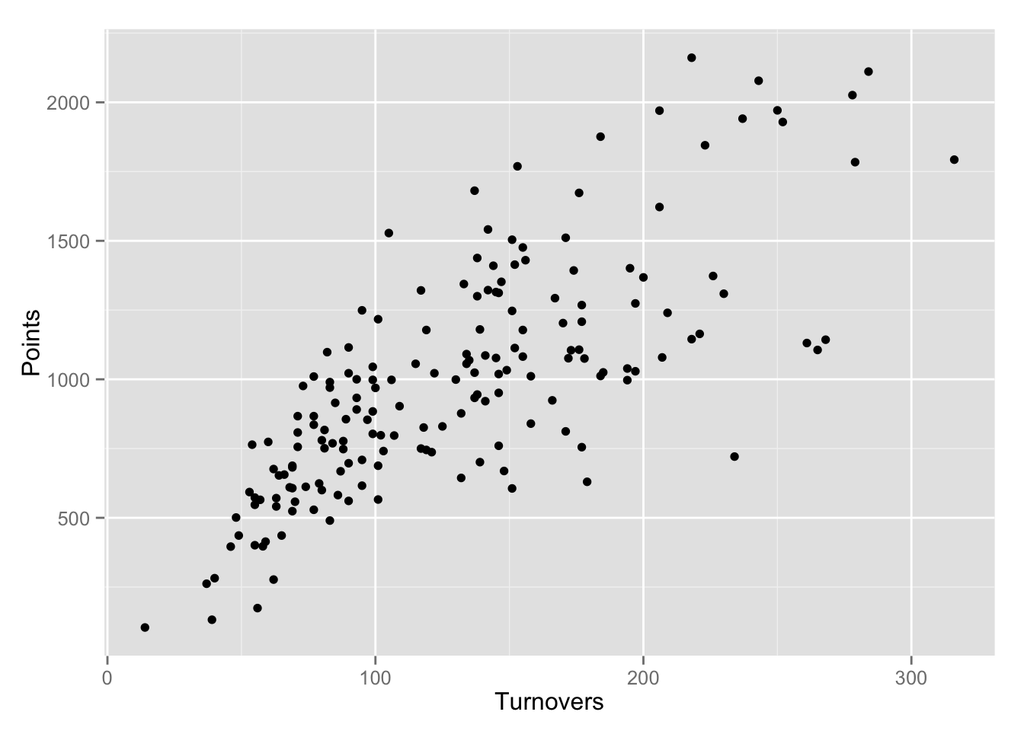

```r
qplot(Turnovers, Points, data=NBAPlayers2011)
```

If there was anything strange with our data, this would probably be where we could catch it. It’s not perfect, but for our purposes this should be fine.

## Linear Model

Now, of course, it’s time to define our linear model. There is an `lm` function built into R that will do this quite easily. The format for a simple linear regression model in R is:

```r
lm(responseVariable~explanatoryVariable, data=dataSet)
```

This will return a y-intercept and a slope.

```r
lm(Points~Turnovers, data=NBAPlayers2011)
```

```
##
## Call:
## lm(formula = Points ~ Turnovers, data = NBAPlayers2011)
##
## Coefficients:
## (Intercept)    Turnovers
##     313.223        5.256
```

Much more helpful than just the y-intercept and slope is the summary of the linear model. As it turns out, the `summary` command isn’t just for data sets; it’s immensely helpful for understanding linear models as well.

```r
summary(lm(Points~Turnovers, data=NBAPlayers2011))
```

```
##
## Call:
## lm(formula = Points ~ Turnovers, data = NBAPlayers2011)
##
## Residuals:
##    Min     1Q Median     3Q    Max
## -822.1 -172.2   -3.9  165.7  702.0
##
## Coefficients:
##             Estimate Std. Error t value Pr(>|t|)
## (Intercept) 313.2231    48.4721   6.462    1e-09 ***
## Turnovers     5.2557     0.3398  15.466   <2e-16 ***
## ---
## Signif. codes:  0 '***' 0.001 '**' 0.01 '*' 0.05 '.' 0.1 ' ' 1
##
## Residual standard error: 269.2 on 174 degrees of freedom
## Multiple R-squared:  0.5789, Adjusted R-squared:  0.5765
## F-statistic: 239.2 on 1 and 174 DF,  p-value: < 2.2e-16
```

## Plots with Linear Models

We can now plot our linear model to our data. This will require use and knowledge of the `ggplot2` package, a review of which is found in the Two-Sample Bootstrap guide.

```r
library(ggplot2)
```

Just as we used `geom_histogram()` to build a histogram, we use `geom_point()` for a scatterplot.

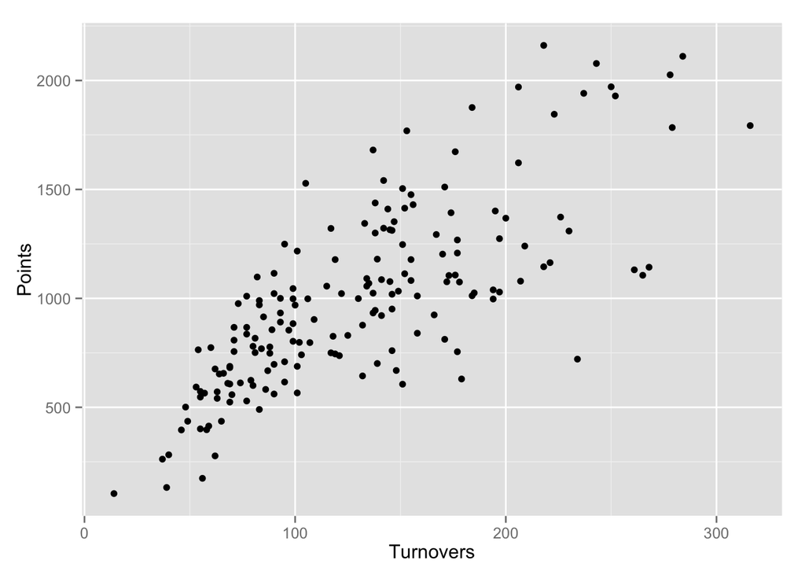

```r
ggplot(NBAPlayers2011, aes(x=Turnovers, y=Points)) + geom_point()
```

Now it’s time to learn the `stat_smooth` command. This simple command plots a smoother to our data. Although there are many different kinds of smoothers, we will use a `method="lm"` argument, which automatically calculates the linear model that we specified above.

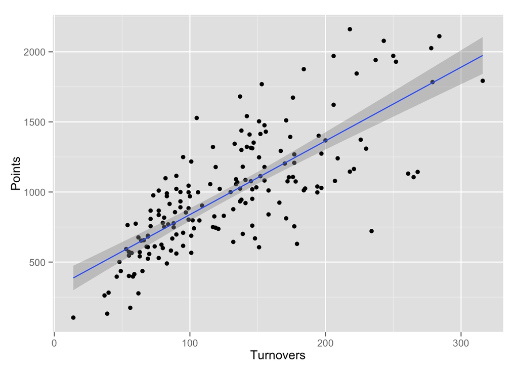

```r
ggplot(NBAPlayers2011, aes(x=Turnovers, y=Points)) + geom_point() + stat_smooth(method="lm")
```